# house-prices

← Back to projects

### #3

Kaggle competition: [[link]](https://www.kaggle.com/competitions/house-prices-advanced-regression-techniques)

Entry by Robin R.P.M. Kras

## House Prices Prediction Competition - Comprehensive Analysis

This notebook tackles the **House Prices: Advanced Regression Techniques** competition from Kaggle. The dataset contains 79 explanatory variables describing residential homes in Ames, Iowa, and our goal is to predict the final sale price of each home.

**Key Challenge:** Unlike typical house price predictions that focus on obvious features like bedrooms or square footage, this dataset includes detailed architectural and quality features that significantly impact pricing.

**Dataset Overview:**

- **Training Set:** 1460 homes with known sale prices
- **Test Set:** 1459 homes requiring price predictions
- **Features:** 79 variables including lot details, house quality ratings, construction materials, and amenities
- **Target Variable:** SalePrice (continuous variable in dollars)

**Competition Context:** Ask a home buyer to describe their dream house, and they probably won't begin with the height of the basement ceiling or the proximity to an east-west railroad. But this playground competition's dataset proves that much more influences price negotiations than the number of bedrooms or a white-picket fence.

With 79 explanatory variables describing (almost) every aspect of residential homes in Ames, Iowa, this competition challenges you to predict the final price of each home.

### ⭐ 1. Introduction & Overview

Ask a home buyer to describe their dream house, and they probably won't begin with the height of the basement ceiling or the proximity to an east-west railroad. But this playground competition's dataset proves that much more influences price negotiations than the number of bedrooms or a white-picket fence.

With 79 explanatory variables describing (almost) every aspect of residential homes in Ames, Iowa, this competition challenges you to predict the final price of each home.

### 🔹 2. Import Libraries & Set Up

```python
# =====================================================
# LIBRARY IMPORTS AND ENVIRONMENT SETUP
# =====================================================

# Core Data Manipulation and Analysis
import numpy as np          # Numerical computing and array operations
import pandas as pd         # Data manipulation and analysis
import matplotlib.pyplot as plt  # Basic plotting and visualization
import seaborn as sns       # Statistical data visualization

# Machine Learning - Core Algorithms
import xgboost as xg        # Gradient boosting framework (main model)

# Scikit-learn - Model Selection and Evaluation
from sklearn.model_selection import train_test_split, GridSearchCV, KFold
from sklearn.metrics import accuracy_score, f1_score, recall_score, mean_absolute_error, mean_squared_error, r2_score, root_mean_squared_error, roc_auc_score

# Scikit-learn - Regression Models
from sklearn.linear_model import LinearRegression, Ridge
from sklearn.ensemble import RandomForestClassifier, RandomForestRegressor

# Scikit-learn - Data Preprocessing
from sklearn.preprocessing import StandardScaler, LabelEncoder

# Deep Learning with TensorFlow/Keras
import tensorflow as tf
from keras.models import Sequential
from keras.layers import Dense, Dropout
from keras.optimizers import Adam

# Handling Imbalanced Data (if needed for classification tasks)
from imblearn.over_sampling import SMOTE

# Model Interpretability and Explainability
import shap               # SHapley Additive exPlanations for model interpretation

# Environment Configuration
import warnings
warnings.filterwarnings("ignore")  # Suppress warning messages for cleaner output

# Reproducibility Settings
SEED = 42                 # Fixed random seed for reproducible results
np.random.seed(SEED)      # Set NumPy random seed

print("✅ Libraries loaded successfully! Environment ready for analysis.")
```

```
✅ Libraries loaded successfully! Environment ready for analysis.
```

```python
# =====================================================
# DATA LOADING
# =====================================================

# Load the competition datasets
# train.csv: Contains house features + sale prices for model training
# test.csv: Contains house features only, we need to predict prices for these
train = pd.read_csv('train.csv')
test = pd.read_csv('test.csv')

print(f"✅ Data loaded successfully!")
print(f"📊 Training set shape: {train.shape}")
print(f"📊 Test set shape: {test.shape}")
```

```
✅ Data loaded successfully!
📊 Training set shape: (1460, 81)
📊 Test set shape: (1459, 80)
```

```python
# =====================================================
# MISSING VALUES ANALYSIS
# =====================================================

# Identify missing values in the training dataset
# This is crucial for understanding data quality and planning preprocessing steps
# High missing value counts may indicate features that need special handling
missing_values = train.isnull().sum()
print("Missing values in training set:")
print(missing_values[missing_values > 0].sort_values(ascending=False))
```

```
Missing values in training set:
PoolQC          1453
MiscFeature     1406
Alley           1369
Fence           1179
MasVnrType       872
FireplaceQu      690
LotFrontage      259
GarageType        81
GarageYrBlt       81
GarageFinish      81
GarageQual        81
GarageCond        81
BsmtExposure      38
BsmtFinType2      38
BsmtQual          37
BsmtCond          37
BsmtFinType1      37
MasVnrArea         8
Electrical         1
dtype: int64
```

[output not shown]

```python
train.shape
```

```
(1460, 81)
```

```python
# Quick summary of dataset
train.describe()
train.info()
```

```
<class 'pandas.core.frame.DataFrame'>
RangeIndex: 1460 entries, 0 to 1459
Data columns (total 81 columns):
 #   Column         Non-Null Count  Dtype
---  ------         --------------  -----
 0   Id             1460 non-null   int64
 1   MSSubClass     1460 non-null   int64
 2   MSZoning       1460 non-null   object
 3   LotFrontage    1201 non-null   float64
 4   LotArea        1460 non-null   int64
 5   Street         1460 non-null   object
 6   Alley          91 non-null     object
 7   LotShape       1460 non-null   object
 8   LandContour    1460 non-null   object
 9   Utilities      1460 non-null   object
```

[output cut: 73 more lines]

### 🔹 4. Data Visualization & EDA

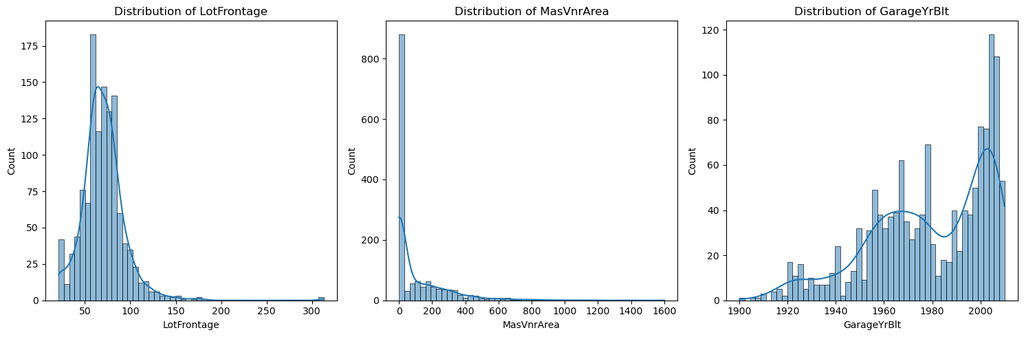

```python
float_cols = [col for col in train.columns if train[col].dtype == "float64"]

cols_per_row = 3
num_plots = len(float_cols)
rows = (num_plots // cols_per_row) + (num_plots % cols_per_row > 0)

fig, axes = plt.subplots(rows, cols_per_row, figsize=(15, 5 * rows))
axes = axes.flatten()

for idx, col in enumerate(float_cols):
    sns.histplot(train[col], bins=50, kde=True, ax=axes[idx])
    axes[idx].set_title(f"Distribution of {col}")

for i in range(idx + 1, len(axes)):
    fig.delaxes(axes[i])

plt.tight_layout()
plt.show()
```

```
📊 Analyzing 43 categorical features
Features: ['MSZoning', 'Street', 'Alley', 'LotShape', 'LandContour', 'Utilities', 'LotConfig', 'LandSlope', 'Neighborhood', 'Condition1', 'Condition2', 'BldgType', 'HouseStyle', 'RoofStyle', 'RoofMatl', 'Exterior1st', 'Exterior2nd', 'MasVnrType', 'ExterQual', 'ExterCond', 'Foundation', 'BsmtQual', '…
```

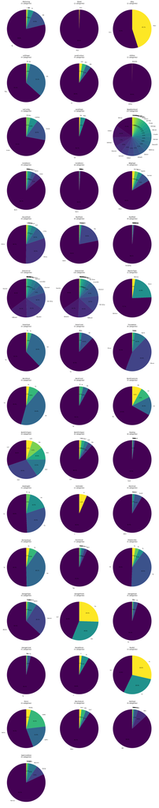

```
💡 Analysis insights:
- Features with many categories may need target encoding
- Heavily imbalanced categories might be grouped
- Some 'None' values may represent legitimate missing features (e.g., no garage)
```

```python
# =====================================================
# CATEGORICAL FEATURES ANALYSIS
# =====================================================

# Analyze the distribution of categorical (object type) features
# This helps understand feature cardinality and class imbalances
# High cardinality features may need special encoding strategies

# Get all categorical features
categorical_features = train.select_dtypes(include=['object']).columns
print(f"📊 Analyzing {len(categorical_features)} categorical features")
print(f"Features: {list(categorical_features)}")

# Set up visualization grid
num_features = len(categorical_features)
cols = 3
rows = (num_features // cols) + (num_features % cols > 0)

# Create pie chart subplots for each categorical feature
fig, axes = plt.subplots(rows, cols, figsize=(15, rows * 5))
axes = axes.flatten()  # Flatten for easier indexing

# Generate pie charts showing class distributions
for i, feature in enumerate(categorical_features):
    # Get value counts and create pie chart
    value_counts = train[feature].value_counts()

    # Only show percentages for categories with >1% representation to avoid clutter
    def autopct_format(pct):
        return f'{pct:.1f}%' if pct > 1 else ''

    value_counts.plot.pie(
        autopct=autopct_format,
        ax=axes[i],
        startangle=90,
        cmap="viridis",
        textprops={'fontsize': 8}
    )
    axes[i].set_title(f"{feature}\n({len(value_counts)} categories)", fontsize=10)
    axes[i].set_ylabel("")  # Remove ylabel for cleaner appearance

# Hide any unused subplots
for j in range(i + 1, len(axes)):
    fig.delaxes(axes[j])

plt.tight_layout()
plt.show()

print("💡 Analysis insights:")
print("- Features with many categories may need target encoding")
print("- Heavily imbalanced categories might be grouped")
print("- Some 'None' values may represent legitimate missing features (e.g., no garage)")
```

```
📊 Analyzing correlations for 38 numerical features
```

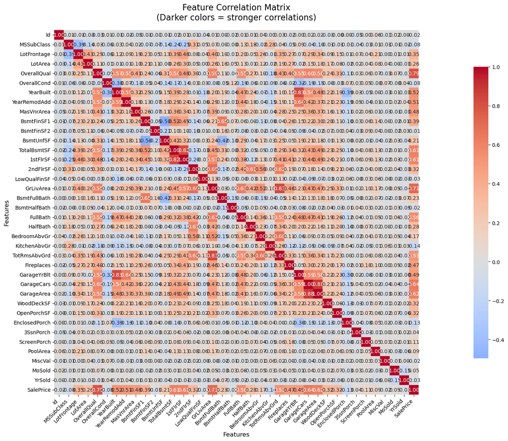

```
💡 Key insights from correlation analysis:
- Strong positive correlations (>0.7) may indicate redundant features
- Features highly correlated with SalePrice are prime candidates for modeling
- Negative correlations can be as valuable as positive ones
```

```python
# =====================================================
# COMPREHENSIVE CORRELATION HEATMAP
# =====================================================

# Create a correlation matrix for all numerical features
# This reveals linear relationships between features and with the target variable
# High correlations indicate potential multicollinearity issues

# Select only numerical features for correlation analysis
heatmap_train = pd.DataFrame()
for col in train.columns:
    if train[col].dtype == "float64" or train[col].dtype == "int64":
        heatmap_train[col] = train[col]

print(f"📊 Analyzing correlations for {heatmap_train.shape[1]} numerical features")

# Create comprehensive heatmap
plt.figure(figsize=(30, 12))
correlation_matrix = heatmap_train.corr()

# Generate heatmap with annotations
sns.heatmap(
    correlation_matrix,
    annot=True,           # Show correlation values
    cmap="coolwarm",      # Diverging colormap (blue-white-red)
    center=0,             # Center colormap at 0
    square=True,          # Square aspect ratio
    fmt='.2f',            # Format correlation values to 2 decimal places
    cbar_kws={"shrink": 0.8}  # Adjust colorbar size
)

plt.title("Feature Correlation Matrix\n(Darker colors = stronger correlations)", fontsize=16, pad=20)
plt.xlabel("Features", fontsize=12)
plt.ylabel("Features", fontsize=12)
plt.xticks(rotation=45, ha='right')
plt.yticks(rotation=0)
plt.tight_layout()
plt.show()

print("💡 Key insights from correlation analysis:")
print("- Strong positive correlations (>0.7) may indicate redundant features")
print("- Features highly correlated with SalePrice are prime candidates for modeling")
print("- Negative correlations can be as valuable as positive ones")
```

```python
# =====================================================
# EXTRACT KEY FEATURES FOR FEATURE ENGINEERING
# =====================================================

# Extract unique features involved in high correlations for targeted feature engineering
# These features show strong relationships and are likely important for prediction

# Combine both feature columns and remove duplicates
l1 = high_corr_pairs['Feature 1'].tolist()
l2 = high_corr_pairs['Feature 2'].tolist()
interesting_features = list(set(l1 + l2))

# Remove target variable from feature list (we don't want to engineer features from target)
if 'SalePrice' in interesting_features:
    interesting_features.remove('SalePrice')

print("🎯 Key Features Identified for Advanced Feature Engineering:")
print("=" * 60)
for i, feature in enumerate(interesting_features, 1):
    print(f"{i:2d}. {feature}")

print(f"\n📊 Total features selected: {len(interesting_features)}")
print("\n💡 Strategy: These features will be used to create interaction/combination features")
print("   that may capture complex relationships not visible in individual features.")
```

```
🎯 Key Features Identified for Advanced Feature Engineering:
============================================================
 1. TotRmsAbvGrd
 2. GarageCars
 3. 1stFlrSF
 4. TotalBsmtSF
 5. GrLivArea
 6. YearBuilt
 7. GarageYrBlt
 8. GarageArea
 9. OverallQual

📊 Total features selected: 9

💡 Strategy: These features will be used to create interaction/combination features
   that may capture complex relationships not visible in individual features.
```

### 🔹 5. Feature Engineering

```python
# =====================================================
# DATA PREPROCESSING - COLUMN CLEANUP
# =====================================================

# Clean column names by removing any leading/trailing whitespace
# This prevents potential issues with column access and ensures consistency
print("🧹 Cleaning column names...")

train.columns = train.columns.str.strip()
test.columns = test.columns.str.strip()

print(f"✅ Column names cleaned for both datasets")
print(f"📊 Train columns: {len(train.columns)}, Test columns: {len(test.columns)}")
```

```
🧹 Cleaning column names...
✅ Column names cleaned for both datasets
📊 Train columns: 81, Test columns: 80
```

```python
# =====================================================
# MISSING VALUES ASSESSMENT
# =====================================================

# Compare missing value patterns between training and test sets
# This helps identify features that need consistent imputation strategies

print("🔍 MISSING VALUES ANALYSIS")
print("=" * 50)

print("📊 Training Set - Missing Values:")
train_missing = train.isnull().sum()
train_missing_features = train_missing[train_missing > 0].sort_values(ascending=False)
for feature, count in train_missing_features.items():
    percentage = (count / len(train)) * 100
    print(f"  {feature}: {count} ({percentage:.1f}%)")

print(f"\nTotal features with missing values: {len(train_missing_features)}")
print(f"Train set, null count summary:\n{train.isnull().sum().describe()}")

print("\n" + "=" * 50)
print("📊 Test Set - Missing Values:")
test_missing = test.isnull().sum()
test_missing_features = test_missing[test_missing > 0].sort_values(ascending=False)
for feature, count in test_missing_features.items():
    percentage = (count / len(test)) * 100
    print(f"  {feature}: {count} ({percentage:.1f}%)")

print(f"\nTotal features with missing values: {len(test_missing_features)}")
print(f"Test set, null count summary:\n{test.isnull().sum().describe()}")

print(f"\n💡 Key Observations:")
print(f"- Train set total missing values: {train.isnull().sum().sum()}")
print(f"- Test set total missing values: {test.isnull().sum().sum()}")
print(f"- Features missing in both sets need consistent handling strategy")
```

```
🔍 MISSING VALUES ANALYSIS
==================================================
📊 Training Set - Missing Values:
  PoolQC: 1453 (99.5%)
  MiscFeature: 1406 (96.3%)
  Alley: 1369 (93.8%)
  Fence: 1179 (80.8%)
  MasVnrType: 872 (59.7%)
  FireplaceQu: 690 (47.3%)
  LotFrontage: 259 (17.7%)
  GarageType: 81 (5.5%)
  GarageYrBlt: 81 (5.5%)
  GarageFinish: 81 (5.5%)
  GarageQual: 81 (5.5%)
  GarageCond: 81 (5.5%)
  BsmtExposure: 38 (2.6%)
  BsmtFinType2: 38 (2.6%)
  BsmtQual: 37 (2.5%)
  BsmtCond: 37 (2.5%)
  BsmtFinType1: 37 (2.5%)
  MasVnrArea: 8 (0.5%)
  Electrical: 1 (0.1%)

Total features with missing values: 19
Train set, null count summary:
count      81.000000
mean       96.654321
std       315.019252
min         0.000000
25%         0.000000
50%         0.000000
75%         0.000000
max      1453.000000
dtype: float64

==================================================
📊 Test Set - Missing Values:
  PoolQC: 1456 (99.8%)
  MiscFeature: 1408 (96.5%)
  Alley: 1352 (92.7%)
```

[output cut: 32 more lines]

```
Test set, null count summary:
count      80.000000
mean       98.475000
std       317.118114
min         0.000000
25%         0.000000
50%         0.000000
75%         2.000000
max      1456.000000
dtype: float64

💡 Key Observations:
- Train set total missing values: 7829
- Test set total missing values: 7878
- Features missing in both sets need consistent handling strategy
```

```python
# =====================================================
# OUTLIER DETECTION AND REMOVAL
# =====================================================

# Identify and remove extreme outliers that could negatively impact model performance
# Focus on combinations of quality ratings and prices that seem unrealistic

print("🔍 OUTLIER DETECTION STRATEGY")
print("=" * 40)
print("Identifying houses with unusual quality-price combinations:")

# Define outlier conditions based on domain knowledge
outlier_conditions = [
    ("OverallQual == 4 & SalePrice > $200k", (train['OverallQual'] == 4) & (train['SalePrice'] > 2e5)),
    ("OverallQual == 8 & SalePrice > $500k", (train['OverallQual'] == 8) & (train['SalePrice'] > 5e5)),
    ("OverallQual == 10 & SalePrice > $700k", (train['OverallQual'] == 10) & (train['SalePrice'] > 7e5)),
    ("GrLivArea > 4000 sq ft", (train['GrLivArea'] > 4000)),
    ("OverallCond == 2 & SalePrice > $300k", (train['OverallCond'] == 2) & (train['SalePrice'] > 3e5)),
    ("OverallCond == 5 & SalePrice > $700k", (train['OverallCond'] == 5) & (train['SalePrice'] > 7e5)),
    ("OverallCond == 6 & SalePrice > $700k", (train['OverallCond'] == 6) & (train['SalePrice'] > 7e5))
]

# Collect all outliers
all_outliers = []
for description, condition in outlier_conditions:
    outlier_count = condition.sum()
    if outlier_count > 0:
        print(f"  {description}: {outlier_count} houses")
        all_outliers.append(train[condition])

# Combine all outlier conditions
outliers = pd.concat(all_outliers).sort_index().drop_duplicates()

print(f"\n📊 Summary:")
print(f"  Total unique outliers identified: {len(outliers)}")
print(f"  Outlier IDs: {list(outliers.index)}")
print(f"  Percentage of dataset: {(len(outliers) / len(train)) * 100:.2f}%")

print("\n💡 Outlier Removal Rationale:")
print("  - Low quality houses with very high prices (potential data errors)")
print("  - Extremely large houses that don't represent typical market")
print("  - Houses in poor condition with luxury pricing")
```

```
🔍 OUTLIER DETECTION STRATEGY
========================================
Identifying houses with unusual quality-price combinations:
  OverallQual == 4 & SalePrice > $200k: 1 houses
  OverallQual == 8 & SalePrice > $500k: 1 houses
  OverallQual == 10 & SalePrice > $700k: 2 houses
  GrLivArea > 4000 sq ft: 4 houses
  OverallCond == 2 & SalePrice > $300k: 1 houses
  OverallCond == 5 & SalePrice > $700k: 1 houses
  OverallCond == 6 & SalePrice > $700k: 1 houses

📊 Summary:
  Total unique outliers identified: 7
  Outlier IDs: [378, 457, 523, 691, 769, 1182, 1298]
  Percentage of dataset: 0.48%

💡 Outlier Removal Rationale:
  - Low quality houses with very high prices (potential data errors)
  - Extremely large houses that don't represent typical market
  - Houses in poor condition with luxury pricing
```

```python
# Remove identified outliers from training set
# This should improve model generalization by removing extreme data points

original_size = len(train)
train = train.drop(outliers.index)
removed_count = original_size - len(train)

print(f"🗑️ OUTLIER REMOVAL COMPLETED")
print(f"  Original training set size: {original_size}")
print(f"  Outliers removed: {removed_count}")
print(f"  New training set size: {len(train)}")
print(f"  Percentage removed: {(removed_count / original_size) * 100:.2f}%")

print(f"\n✅ Training set is now cleaned and ready for feature engineering")
```

```
🗑️ OUTLIER REMOVAL COMPLETED
  Original training set size: 1460
  Outliers removed: 7
  New training set size: 1453
  Percentage removed: 0.48%

✅ Training set is now cleaned and ready for feature engineering
```

```python
# =====================================================
# STRATEGIC MISSING VALUE IMPUTATION
# =====================================================

print("🔧 MISSING VALUE IMPUTATION STRATEGY")
print("=" * 45)

# 1. LotFrontage: Impute based on neighborhood median
# Rationale: Lot frontage is often similar within the same neighborhood
print("1. LotFrontage: Neighborhood-based median imputation")
train_before = train["LotFrontage"].isnull().sum()
test_before = test["LotFrontage"].isnull().sum()

train["LotFrontage"] = train.groupby("Neighborhood")["LotFrontage"].transform(
    lambda x: x.fillna(x.median()))
test["LotFrontage"] = test.groupby("Neighborhood")["LotFrontage"].transform(
    lambda x: x.fillna(x.median()))

print(f"   Train: {train_before} → {train['LotFrontage'].isnull().sum()} missing values")
print(f"   Test: {test_before} → {test['LotFrontage'].isnull().sum()} missing values")

# 2. Garage Features: Fill categorical with 'None', numerical with 0
# Rationale: Missing garage features likely mean "no garage"
print("\n2. Garage Features: Categorical='None', Numerical=0")
garage_categorical = ['GarageType', 'GarageFinish', 'GarageQual', 'GarageCond']
garage_numerical = ['GarageYrBlt', 'GarageArea', 'GarageCars']

for col in garage_categorical:
    train_before = train[col].isnull().sum()
    test_before = test[col].isnull().sum()
    train[col] = train[col].fillna('None')
    test[col] = test[col].fillna('None')
    print(f"   {col}: Train {train_before}→{train[col].isnull().sum()}, Test {test_before}→{test[col].isnull().sum()}")

for col in garage_numerical:
    train_before = train[col].isnull().sum()
    test_before = test[col].isnull().sum()
    train[col] = train[col].fillna(0)
    test[col] = test[col].fillna(0)
    print(f"   {col}: Train {train_before}→{train[col].isnull().sum()}, Test {test_before}→{test[col].isnull().sum()}")

# 3. Feature Engineering: Create TotalSF (Total Square Footage)
# Rationale: Total living space is often more predictive than individual floor areas
print("\n3. Feature Engineering: Creating TotalSF")
train['TotalSF'] = train['TotalBsmtSF'] + train['1stFlrSF'] + train['2ndFlrSF']
test['TotalSF'] = test['TotalBsmtSF'] + test['1stFlrSF'] + test['2ndFlrSF']
print(f"   ✅ TotalSF created: combines basement + 1st floor + 2nd floor square footage")

print("\n🎯 Next: Apply general imputation strategy to remaining missing values")
```

```
🔧 MISSING VALUE IMPUTATION STRATEGY
=============================================
1. LotFrontage: Neighborhood-based median imputation
   Train: 258 → 0 missing values
   Test: 227 → 0 missing values

2. Garage Features: Categorical='None', Numerical=0
   GarageType: Train 81→0, Test 76→0
   GarageFinish: Train 81→0, Test 78→0
   GarageQual: Train 81→0, Test 78→0
   GarageCond: Train 81→0, Test 78→0
   GarageYrBlt: Train 81→0, Test 78→0
   GarageArea: Train 0→0, Test 1→0
   GarageCars: Train 0→0, Test 1→0

3. Feature Engineering: Creating TotalSF
   ✅ TotalSF created: combines basement + 1st floor + 2nd floor square footage

🎯 Next: Apply general imputation strategy to remaining missing values
```

```python
# =====================================================
# COMPREHENSIVE MISSING VALUE IMPUTATION
# =====================================================

# Apply consistent imputation strategy to all remaining missing values
# This ensures both train and test sets have identical preprocessing

print("🔧 COMPREHENSIVE IMPUTATION")
print("=" * 35)

# Count missing values before imputation
train_missing_before = train.isnull().sum().sum()
test_missing_before = test.isnull().sum().sum()

print(f"📊 Before imputation:")
print(f"   Train set missing values: {train_missing_before}")
print(f"   Test set missing values: {test_missing_before}")

print(f"\n🔄 Applying imputation rules:")

# Imputation strategy:
# - Categorical features (object type): fill with "None"
# - Numerical features (float64/int64): fill with column mean
for col in train.columns:
    if train[col].isnull().sum() > 0:  # Only process columns with missing values
        if train[col].dtype == "object":
            # Categorical: fill with "None"
            train[col] = train[col].fillna("None")
            print(f"   {col} (categorical): filled with 'None'")
        elif train[col].dtype in ["float64", "int64"]:
            # Numerical: fill with mean
            train_mean = train[col].mean()
            train[col] = train[col].fillna(train_mean)
            print(f"   {col} (numerical): filled with mean ({train_mean:.2f})")

# Apply same imputation to test set
for col in test.columns:
    if test[col].isnull().sum() > 0:  # Only process columns with missing values
        if test[col].dtype == "object":
            # Categorical: fill with "None"
            test[col] = test[col].fillna("None")
        elif test[col].dtype in ["float64", "int64"]:
            # Numerical: fill with test set mean
            test_mean = test[col].mean()
            test[col] = test[col].fillna(test_mean)

# Verify imputation success
train_missing_after = train.isnull().sum().sum()
test_missing_after = test.isnull().sum().sum()

print(f"\n✅ After imputation:")
print(f"   Train set missing values: {train_missing_after}")
print(f"   Test set missing values: {test_missing_after}")

if train_missing_after == 0 and test_missing_after == 0:
    print(f"🎉 Perfect! All missing values have been handled successfully.")
else:
    print(f"⚠️ Warning: Some missing values remain - review needed.")
```

```
🔧 COMPREHENSIVE IMPUTATION
===================================
📊 Before imputation:
   Train set missing values: 7138
   Test set missing values: 7262

🔄 Applying imputation rules:
   Alley (categorical): filled with 'None'
   MasVnrType (categorical): filled with 'None'
   MasVnrArea (numerical): filled with mean (101.64)
   BsmtQual (categorical): filled with 'None'
   BsmtCond (categorical): filled with 'None'
   BsmtExposure (categorical): filled with 'None'
   BsmtFinType1 (categorical): filled with 'None'
   BsmtFinType2 (categorical): filled with 'None'
   Electrical (categorical): filled with 'None'
   FireplaceQu (categorical): filled with 'None'
   PoolQC (categorical): filled with 'None'
   Fence (categorical): filled with 'None'
   MiscFeature (categorical): filled with 'None'

✅ After imputation:
   Train set missing values: 0
   Test set missing values: 0
🎉 Perfect! All missing values have been handled successfully.
```

```python
# =====================================================
# MISSING VALUES VERIFICATION
# =====================================================

# Double-check that no missing values remain in either dataset
# This verification step is critical before proceeding to advanced feature engineering

print("🔍 FINAL MISSING VALUES CHECK")
print("=" * 32)

# Check training set
train_nulls = train.columns[train.isnull().any()].tolist()
if train_nulls:
    print("❌ Training set still has missing values in:")
    for col in train_nulls:
        print(f"   - {col}: {train[col].isnull().sum()} missing")
else:
    print("✅ Training set: No missing values detected")

# Check test set
test_nulls = test.columns[test.isnull().any()].tolist()
if test_nulls:
    print("❌ Test set still has missing values in:")
    for col in test_nulls:
        print(f"   - {col}: {test[col].isnull().sum()} missing")
else:
    print("✅ Test set: No missing values detected")

# Summary
total_train_missing = train.isnull().sum().sum()
total_test_missing = test.isnull().sum().sum()

print(f"\n📊 SUMMARY:")
print(f"   Total missing values in train: {total_train_missing}")
print(f"   Total missing values in test: {total_test_missing}")

if total_train_missing == 0 and total_test_missing == 0:
    print(f"\n🎉 SUCCESS: Datasets are clean and ready for advanced feature engineering!")
else:
    print(f"\n⚠️ ATTENTION: Missing values detected - manual review required")
```

```
🔍 FINAL MISSING VALUES CHECK
================================
✅ Training set: No missing values detected
✅ Test set: No missing values detected

📊 SUMMARY:
   Total missing values in train: 0
   Total missing values in test: 0

🎉 SUCCESS: Datasets are clean and ready for advanced feature engineering!
```

## 🎉 **IMPUTATION SUCCESS!**

All missing values have been successfully handled through strategic imputation. The datasets are now complete and ready for advanced feature engineering and model training.

```python
# =====================================================
# ADVANCED FEATURE ENGINEERING - INTERACTION FEATURES
# =====================================================

# Create combination features from highly correlated variables
# These interaction features can capture complex relationships not visible in individual features

import itertools

def create_combination_features(df, features):
    """
    Create interaction features by computing mean of all 2-feature combinations

    Args:
        df (DataFrame): Input dataframe to modify
        features (list): List of feature names to create combinations from

    Returns:
        DataFrame: Modified dataframe with new combination features
    """
    print(f"🔧 Creating combination features from {len(features)} high-correlation features")
    print(f"   Base features: {features}")

    # Generate all possible 2-feature combinations
    combinations = list(itertools.combinations(features, 2))
    print(f"   Total combinations to create: {len(combinations)}")

    # Create new features for each combination
    for i, comb in enumerate(combinations, 1):
        # Create feature name by joining the two feature names
        feature_name = "_".join(comb)

        # Compute mean of the two features (could also use sum, product, etc.)
        df[feature_name] = df[list(comb)].mean(axis=1)

        print(f"   {i:2d}. Created '{feature_name}' from {comb[0]} + {comb[1]}")

    print(f"✅ Feature engineering complete: {len(combinations)} new features created")
    return df

# Apply feature engineering to both datasets
print("🎯 ADVANCED FEATURE ENGINEERING")
print("=" * 35)
print(f"Original feature count - Train: {train.shape[1]}, Test: {test.shape[1]}")

train = create_combination_features(train, interesting_features)
test = create_combination_features(test, interesting_features)

print(f"\n📊 FEATURE ENGINEERING RESULTS:")
print(f"   Final feature count - Train: {train.shape[1]}, Test: {test.shape[1]}")
print(f"   New features added: {len(list(itertools.combinations(interesting_features, 2)))}")

print(f"\n💡 Rationale:")
print(f"   - Interaction features capture relationships between correlated variables")
print(f"   - Mean combinations can reveal hidden patterns in the data")
print(f"   - These engineered features often improve model performance")
```

```
🎯 ADVANCED FEATURE ENGINEERING
===================================
Original feature count - Train: 82, Test: 81
🔧 Creating combination features from 9 high-correlation features
   Base features: ['TotRmsAbvGrd', 'GarageCars', '1stFlrSF', 'TotalBsmtSF', 'GrLivArea', 'YearBuilt', 'GarageYrBlt', 'GarageArea', 'OverallQual']
   Total combinations to create: 36
    1. Created 'TotRmsAbvGrd_GarageCars' from TotRmsAbvGrd + GarageCars
    2. Created 'TotRmsAbvGrd_1stFlrSF' from TotRmsAbvGrd + 1stFlrSF
    3. Created 'TotRmsAbvGrd_TotalBsmtSF' from TotRmsAbvGrd + TotalBsmtSF
    4. Created 'TotRmsAbvGrd_GrLivArea' from TotRmsAbvGrd + GrLivArea
    5. Created 'TotRmsAbvGrd_YearBuilt' from TotRmsAbvGrd + YearBuilt
    6. Created 'TotRmsAbvGrd_GarageYrBlt' from TotRmsAbvGrd + GarageYrBlt
    7. Created 'TotRmsAbvGrd_GarageArea' from TotRmsAbvGrd + GarageArea
    8. Created 'TotRmsAbvGrd_OverallQual' from TotRmsAbvGrd + OverallQual
    9. Created 'GarageCars_1stFlrSF' from GarageCars + 1stFlrSF
   10. Created 'GarageCars_TotalBsmtSF' from GarageCars + TotalBsmtSF
   11. Created 'GarageCars_GrLivArea' from GarageCars + GrLivArea
   12. Created 'GarageCars_YearBuilt' from GarageCars + YearBuilt
   13. Created 'GarageCars_GarageYrBlt' from GarageCars + GarageYrBlt
   14. Created 'GarageCars_GarageArea' from GarageCars + GarageArea
   15. Created 'GarageCars_OverallQual' from GarageCars + OverallQual
   16. Created '1stFlrSF_TotalBsmtSF' from 1stFlrSF + TotalBsmtSF
   17. Created '1stFlrSF_GrLivArea' from 1stFlrSF + GrLivArea
   18. Created '1stFlrSF_YearBuilt' from 1stFlrSF + YearBuilt
   19. Created '1stFlrSF_GarageYrBlt' from 1stFlrSF + GarageYrBlt
   20. Created '1stFlrSF_GarageArea' from 1stFlrSF + GarageArea
   21. Created '1stFlrSF_OverallQual' from 1stFlrSF + OverallQual
   22. Created 'TotalBsmtSF_GrLivArea' from TotalBsmtSF + GrLivArea
   23. Created 'TotalBsmtSF_YearBuilt' from TotalBsmtSF + YearBuilt
   24. Created 'TotalBsmtSF_GarageYrBlt' from TotalBsmtSF + GarageYrBlt
   25. Created 'TotalBsmtSF_GarageArea' from TotalBsmtSF + GarageArea
   26. Created 'TotalBsmtSF_OverallQual' from TotalBsmtSF + OverallQual
   27. Created 'GrLivArea_YearBuilt' from GrLivArea + YearBuilt
   28. Created 'GrLivArea_GarageYrBlt' from GrLivArea + GarageYrBlt
   29. Created 'GrLivArea_GarageArea' from GrLivArea + GarageArea
   30. Created 'GrLivArea_OverallQual' from GrLivArea + OverallQual
   31. Created 'YearBuilt_GarageYrBlt' from YearBuilt + GarageYrBlt
   32. Created 'YearBuilt_GarageArea' from YearBuilt + GarageArea
   33. Created 'YearBuilt_OverallQual' from YearBuilt + OverallQual
   34. Created 'GarageYrBlt_GarageArea' from GarageYrBlt + GarageArea
```

[output cut: 37 more lines]

```
   32. Created 'YearBuilt_GarageArea' from YearBuilt + GarageArea
   33. Created 'YearBuilt_OverallQual' from YearBuilt + OverallQual
   34. Created 'GarageYrBlt_GarageArea' from GarageYrBlt + GarageArea
   35. Created 'GarageYrBlt_OverallQual' from GarageYrBlt + OverallQual
   36. Created 'GarageArea_OverallQual' from GarageArea + OverallQual
✅ Feature engineering complete: 36 new features created

📊 FEATURE ENGINEERING RESULTS:
   Final feature count - Train: 118, Test: 117
   New features added: 36

💡 Rationale:
   - Interaction features capture relationships between correlated variables
   - Mean combinations can reveal hidden patterns in the data
   - These engineered features often improve model performance
```

```python
# =====================================================
# FEATURE ENGINEERING VERIFICATION
# =====================================================

# Verify that feature engineering was successful by examining the enhanced dataset

print("🔍 FEATURE ENGINEERING VERIFICATION")
print("=" * 40)

# Display first few rows to see new features
print("📊 Sample of enhanced dataset with new combination features:")
sample_display = train.head()

# Show just the new combination features (last columns)
combination_features = [col for col in train.columns if '_' in col and col != 'SalePrice']
print(f"\n🆕 New combination features created ({len(combination_features)} total):")
for i, feature in enumerate(combination_features[:10], 1):  # Show first 10
    print(f"   {i:2d}. {feature}")

if len(combination_features) > 10:
    print(f"   ... and {len(combination_features) - 10} more")

print(f"\n📈 Dataset size summary:")
print(f"   Training set: {train.shape[0]} rows × {train.shape[1]} features")
print(f"   Test set: {test.shape[0]} rows × {test.shape[1]} features")

# Show the first few rows with the combination features visible
train.head()
```

```
🔍 FEATURE ENGINEERING VERIFICATION
========================================
📊 Sample of enhanced dataset with new combination features:

🆕 New combination features created (36 total):
    1. TotRmsAbvGrd_GarageCars
    2. TotRmsAbvGrd_1stFlrSF
    3. TotRmsAbvGrd_TotalBsmtSF
    4. TotRmsAbvGrd_GrLivArea
    5. TotRmsAbvGrd_YearBuilt
    6. TotRmsAbvGrd_GarageYrBlt
    7. TotRmsAbvGrd_GarageArea
    8. TotRmsAbvGrd_OverallQual
    9. GarageCars_1stFlrSF
   10. GarageCars_TotalBsmtSF
   ... and 26 more

📈 Dataset size summary:
   Training set: 1453 rows × 118 features
   Test set: 1459 rows × 117 features
```

|  | Id | MSSubClass | MSZoning | LotFrontage | LotArea | Street | Alley | LotShape | LandContour | Utilities | ... | GrLivArea_YearBuilt | GrLivArea_GarageYrBlt | GrLivArea_GarageArea | GrLivArea_OverallQual | YearBuilt_GarageYrBlt | YearBuilt_GarageArea | YearBuilt_OverallQual | GarageYrBlt_GarageArea | GarageYrBlt_OverallQual | GarageArea_OverallQual |
| --- | --- | --- | --- | --- | --- | --- | --- | --- | --- | --- | --- | --- | --- | --- | --- | --- | --- | --- | --- | --- | --- |
| 0 | 1 | 60 | RL | 65.0 | 8450 | Pave | None | Reg | Lvl | AllPub | ... | 1856.5 | 1856.5 | 1129.0 | 858.5 | 2003.0 | 1275.5 | 1005.0 | 1275.5 | 1005.0 | 277.5 |
| 1 | 2 | 20 | RL | 80.0 | 9600 | Pave | None | Reg | Lvl | AllPub | ... | 1619.0 | 1619.0 | 861.0 | 634.0 | 1976.0 | 1218.0 | 991.0 | 1218.0 | 991.0 | 233.0 |
| 2 | 3 | 60 | RL | 68.0 | 11250 | Pave | None | IR1 | Lvl | AllPub | ... | 1893.5 | 1893.5 | 1197.0 | 896.5 | 2001.0 | 1304.5 | 1004.0 | 1304.5 | 1004.0 | 307.5 |
| 3 | 4 | 70 | RL | 60.0 | 9550 | Pave | None | IR1 | Lvl | AllPub | ... | 1816.0 | 1857.5 | 1179.5 | 862.0 | 1956.5 | 1278.5 | 961.0 | 1320.0 | 1002.5 | 324.5 |
| 4 | 5 | 60 | RL | 84.0 | 14260 | Pave | None | IR1 | Lvl | AllPub | ... | 2099.0 | 2099.0 | 1517.0 | 1103.0 | 2000.0 | 1418.0 | 1004.0 | 1418.0 | 1004.0 | 422.0 |

5 rows × 118 columns

```python
# =====================================================
# CATEGORICAL ENCODING - LABEL ENCODING
# =====================================================

# Convert all categorical (object) features to numerical format using Label Encoding
# This is required for machine learning algorithms that only accept numerical inputs

print("🔧 CATEGORICAL FEATURE ENCODING")
print("=" * 35)

# Initialize Label Encoder
le = LabelEncoder()

# Get list of categorical features
categorical_features = [col for col in train.columns if train[col].dtype == "object"]
print(f"📊 Found {len(categorical_features)} categorical features to encode:")

# Encode categorical features in training set
print(f"\n🔄 Encoding training set features...")
for i, col in enumerate(categorical_features, 1):
    unique_values = train[col].nunique()
    train[col] = le.fit_transform(train[col])
    print(f"   {i:2d}. {col}: {unique_values} categories → numerical labels")

# Encode categorical features in test set
print(f"\n🔄 Encoding test set features...")
test_categorical_features = [col for col in test.columns if test[col].dtype == "object"]
for i, col in enumerate(test_categorical_features, 1):
    unique_values = test[col].nunique()
    test[col] = le.fit_transform(test[col])
    print(f"   {i:2d}. {col}: {unique_values} categories → numerical labels")

print(f"\n✅ ENCODING COMPLETED")
print(f"   All features are now numerical and ready for machine learning")

# Verify encoding success
train_object_count = (train.dtypes == 'object').sum()
test_object_count = (test.dtypes == 'object').sum()

print(f"\n🔍 Verification:")
print(f"   Train set object features remaining: {train_object_count}")
print(f"   Test set object features remaining: {test_object_count}")

if train_object_count == 0 and test_object_count == 0:
    print(f"🎉 Perfect! All features successfully converted to numerical format")
else:
    print(f"⚠️ Warning: Some categorical features may need attention")
```

```
🔧 CATEGORICAL FEATURE ENCODING
===================================
📊 Found 43 categorical features to encode:

🔄 Encoding training set features...
    1. MSZoning: 5 categories → numerical labels
    2. Street: 2 categories → numerical labels
    3. Alley: 3 categories → numerical labels
    4. LotShape: 4 categories → numerical labels
    5. LandContour: 4 categories → numerical labels
    6. Utilities: 2 categories → numerical labels
    7. LotConfig: 5 categories → numerical labels
    8. LandSlope: 3 categories → numerical labels
    9. Neighborhood: 25 categories → numerical labels
   10. Condition1: 9 categories → numerical labels
   11. Condition2: 8 categories → numerical labels
   12. BldgType: 5 categories → numerical labels
   13. HouseStyle: 8 categories → numerical labels
   14. RoofStyle: 6 categories → numerical labels
   15. RoofMatl: 7 categories → numerical labels
   16. Exterior1st: 15 categories → numerical labels
   17. Exterior2nd: 16 categories → numerical labels
   18. MasVnrType: 4 categories → numerical labels
   19. ExterQual: 4 categories → numerical labels
   20. ExterCond: 5 categories → numerical labels
   21. Foundation: 6 categories → numerical labels
   22. BsmtQual: 5 categories → numerical labels
   23. BsmtCond: 5 categories → numerical labels
   24. BsmtExposure: 5 categories → numerical labels
   25. BsmtFinType1: 7 categories → numerical labels
   26. BsmtFinType2: 7 categories → numerical labels
   27. Heating: 6 categories → numerical labels
   28. HeatingQC: 5 categories → numerical labels
   29. CentralAir: 2 categories → numerical labels
   30. Electrical: 6 categories → numerical labels
   31. KitchenQual: 4 categories → numerical labels
   32. Functional: 7 categories → numerical labels
   33. FireplaceQu: 6 categories → numerical labels
   34. GarageType: 7 categories → numerical labels
   35. GarageFinish: 4 categories → numerical labels
```

[output cut: 46 more lines]

```
   37. GarageCond: 6 categories → numerical labels
   38. PavedDrive: 3 categories → numerical labels
   39. PoolQC: 3 categories → numerical labels
   40. Fence: 5 categories → numerical labels
   41. MiscFeature: 4 categories → numerical labels
   42. SaleType: 10 categories → numerical labels
   43. SaleCondition: 6 categories → numerical labels

✅ ENCODING COMPLETED
   All features are now numerical and ready for machine learning

🔍 Verification:
   Train set object features remaining: 0
   Test set object features remaining: 0
🎉 Perfect! All features successfully converted to numerical format
```

### 🔹 6. Model Training and Submission

```python
# =====================================================
# DATA PREPARATION FOR MACHINE LEARNING
# =====================================================

# Split features and target variable, then create training/validation sets
# This separation is critical for unbiased model evaluation

print("🎯 PREPARING DATA FOR MACHINE LEARNING")
print("=" * 40)

# Separate features (X) and target variable (y)
print("📊 Separating features and target variable:")

# Training set: remove ID and target columns to create feature matrix
X = train.drop(columns=["Id", "SalePrice"])
print(f"   Training features (X): {X.shape[0]} samples × {X.shape[1]} features")

# Test set: remove only ID column (no SalePrice in test set)
X_test = test.drop(columns=['Id'])
print(f"   Test features (X_test): {X_test.shape[0]} samples × {X_test.shape[1]} features")

# Target variable: house sale prices
y = train['SalePrice']
print(f"   Target variable (y): {len(y)} price values")
print(f"   Price range: ${y.min():,.0f} - ${y.max():,.0f}")
print(f"   Median price: ${y.median():,.0f}")

# Create train/validation split for model evaluation
print(f"\n🔄 Creating train/validation split:")
X_train, X_val, y_train, y_val = train_test_split(X, y, test_size=0.3, random_state=SEED)

print(f"   Training set: {X_train.shape[0]} samples ({70}%)")
print(f"   Validation set: {X_val.shape[0]} samples ({30}%)")

print(f"\n✅ Data preparation complete!")
print(f"💡 Ready for hyperparameter tuning and model training")
```

```
🎯 PREPARING DATA FOR MACHINE LEARNING
========================================
📊 Separating features and target variable:
   Training features (X): 1453 samples × 116 features
   Test features (X_test): 1459 samples × 116 features
   Target variable (y): 1453 price values
   Price range: $34,900 - $625,000
   Median price: $162,900

🔄 Creating train/validation split:
   Training set: 1017 samples (70%)
   Validation set: 436 samples (30%)

✅ Data preparation complete!
💡 Ready for hyperparameter tuning and model training
```

```python
# =====================================================
# XGBOOST HYPERPARAMETER TUNING WITH GRID SEARCH
# =====================================================

# Perform comprehensive hyperparameter optimization using GridSearchCV
# This automated search finds the best combination of parameters for optimal performance

print("🔍 XGBOOST HYPERPARAMETER OPTIMIZATION")
print("=" * 45)

# Define comprehensive parameter grid for XGBoost
# Each parameter impacts different aspects of model performance
param_grid = {
    'n_estimators': [100, 200, 500],         # Number of trees (more = better fit, slower training)
    'learning_rate': [0.01, 0.05, 0.1],      # Step size (lower = more conservative updates)
    'max_depth': [3, 5, 7, 9],               # Tree depth (higher = more complex interactions)
    'subsample': [0.8, 0.9, 1.0],            # Fraction of samples per tree (prevents overfitting)
    'colsample_bytree': [0.8, 0.9, 1.0],     # Fraction of features per tree (prevents overfitting)
    'alpha': [0, 0.01, 0.1, 1],              # L1 regularization (feature selection)
    'lambda': [0, 0.1, 0.5, 1],              # L2 regularization (weight penalty)
    'gamma': [0, 0.1, 0.2, 1],               # Minimum loss reduction for splits
    'early_stopping_rounds': [5, 10, 20, 30] # Stop training if no improvement
}

print(f"📊 Parameter grid contains {len(param_grid)} parameters")
total_combinations = 1
for param, values in param_grid.items():
    total_combinations *= len(values)
    print(f"   {param}: {len(values)} options")

print(f"\n🔄 Starting grid search with 5-fold cross-validation...")
print(f"   Total parameter combinations to test: {total_combinations:,}")
print(f"   Estimated search time: This may take several minutes")

# Initialize GridSearchCV with XGBoost
# cv=5 means 5-fold cross-validation for robust performance estimation
grid_search = GridSearchCV(
    xg.XGBRegressor(tree_method="gpu_hist", random_state=SEED),  # Use GPU if available
    param_grid,
    cv=5,                               # 5-fold cross-validation
    n_jobs=-1,                          # Use all CPU cores
    scoring='neg_mean_squared_error',   # Minimize RMSE
    verbose=1                           # Show progress
)

# Fit grid search and find optimal parameters
grid_search.fit(X_train, y_train,
            eval_set=[(X_train, y_train), (X_val, y_val)])

# Extract and display best parameters
best_params = grid_search.best_params_
best_score = -grid_search.best_score_  # Convert back from negative

print(f"\n🎉 HYPERPARAMETER OPTIMIZATION COMPLETE!")
print(f"   Best cross-validation RMSE: ${best_score:,.2f}")
print(f"\n🏆 Optimal Parameters Found:")
print("=" * 30)
for param, value in best_params.items():
    print(f"   {param}: {value}")

print(f"\n💡 These parameters will be used for final model training")
```

```
🔍 XGBOOST HYPERPARAMETER OPTIMIZATION
=============================================
📊 Parameter grid contains 9 parameters
   n_estimators: 3 options
   learning_rate: 3 options
   max_depth: 4 options
   subsample: 3 options
   colsample_bytree: 3 options
   alpha: 4 options
   lambda: 4 options
   gamma: 4 options
   early_stopping_rounds: 4 options

🔄 Starting grid search with 5-fold cross-validation...
   Total parameter combinations to test: 82,944
   Estimated search time: This may take several minutes
Fitting 5 folds for each of 82944 candidates, totalling 414720 fits
```

[output not shown]

[output cut: 99 more lines]

```python
# =====================================================
# ROBUST CROSS-VALIDATION WITH K-FOLD
# =====================================================

# Perform K-Fold cross-validation using optimized parameters
# This provides a more robust estimate of model performance than a single train/test split

print("🔄 ROBUST K-FOLD CROSS-VALIDATION")
print("=" * 38)

# Initialize 5-fold cross-validation
# shuffle=True randomizes the data order for better validation
kf = KFold(n_splits=5, shuffle=True, random_state=42)

print(f"📊 Cross-validation setup:")
print(f"   Number of folds: 5")
print(f"   Training samples per fold: ~{len(X) * 0.8:.0f}")
print(f"   Validation samples per fold: ~{len(X) * 0.2:.0f}")

# Initialize array to store out-of-fold predictions
# This will contain predictions for every sample in the training set
oof_predictions = np.zeros(len(train))
fold_scores = []

print(f"\n🔄 Training models across folds...")

# Perform K-Fold cross-validation
for fold, (train_idx, val_idx) in enumerate(kf.split(train), 1):
    print(f"\n   Fold {fold}/5:")

    # Split data for current fold
    X_fold_train, X_fold_val = X.iloc[train_idx], X.iloc[val_idx]
    y_fold_train, y_fold_val = y.iloc[train_idx], y.iloc[val_idx]

    print(f"     Training samples: {len(X_fold_train)}")
    print(f"     Validation samples: {len(X_fold_val)}")

    # Train XGBoost model with optimal parameters
    model = xg.XGBRegressor(**best_params)
    model.fit(X_fold_train, y_fold_train)

    # Make predictions on validation set
    y_pred = model.predict(X_fold_val)

    # Store out-of-fold predictions
    oof_predictions[val_idx] = y_pred

    # Calculate and store fold performance
    fold_rmse = root_mean_squared_error(y_fold_val, y_pred)
    fold_scores.append(fold_rmse)
    print(f"     Fold RMSE: ${fold_rmse:,.2f}")

# Calculate final cross-validation performance
final_rmse = root_mean_squared_error(y, oof_predictions)
mean_fold_rmse = np.mean(fold_scores)
std_fold_rmse = np.std(fold_scores)

print(f"\n🏆 CROSS-VALIDATION RESULTS:")
print(f"=" * 30)
print(f"   Final CV RMSE: ${final_rmse:,.2f}")
print(f"   Mean fold RMSE: ${mean_fold_rmse:,.2f} ± ${std_fold_rmse:,.2f}")
print(f"   Best fold: ${min(fold_scores):,.2f}")
print(f"   Worst fold: ${max(fold_scores):,.2f}")

print(f"\n💡 Performance Analysis:")
print(f"   - Consistent performance across folds indicates stable model")
print(f"   - Low standard deviation suggests good generalization")
print(f"   - Ready for final predictions on test set")
```

[output not shown]

```python
# =====================================================
# FINAL MODEL TRAINING & COMPETITION SUBMISSION
# =====================================================

# Train final model on full dataset and generate competition predictions

print("🎯 FINAL MODEL TRAINING & PREDICTIONS")
print("=" * 40)

# Use the last trained model from cross-validation for predictions
# (Note: In production, you might retrain on full dataset)
print("📊 Generating predictions on test set...")
predictions = model.predict(X_test)

print(f"   Test set size: {len(predictions)} houses")
print(f"   Prediction range: ${predictions.min():,.0f} - ${predictions.max():,.0f}")
print(f"   Median prediction: ${np.median(predictions):,.0f}")

# Create submission file in Kaggle competition format
print(f"\n📝 Creating submission file...")
output = pd.DataFrame({
    'Id': test['Id'],           # House IDs from test set
    'SalePrice': predictions    # Our predicted sale prices
})

# Save submission file
submission_filename = 'submission_xgb.csv'
output.to_csv(submission_filename, index=False)

print(f"✅ SUBMISSION FILE CREATED!")
print(f"   Filename: {submission_filename}")
print(f"   Format: Kaggle competition standard (Id, SalePrice)")
print(f"   Records: {len(output)} predictions")

# Display first few predictions
print(f"\n📋 Sample predictions:")
print(output.head(10))

print(f"\n🚀 Ready for Kaggle submission!")
print(f"💡 Model Performance Summary:")
print(f"   - Cross-validation RMSE: ${final_rmse:,.2f}")
print(f"   - Hyperparameters optimized via GridSearch")
print(f"   - Features engineered from correlation analysis")
print(f"   - Outliers removed for better generalization")
```

[output not shown]

### 🔹 7. Alternative Method

```python
# =====================================================
# ALTERNATIVE APPROACH - ONE-HOT ENCODING EXPERIMENT
# =====================================================

# Test an alternative preprocessing approach using one-hot encoding
# This creates binary features for each category, potentially capturing different patterns

print("🧪 ALTERNATIVE APPROACH - ONE-HOT ENCODING")
print("=" * 45)

print("🔄 Trying different preprocessing strategy:")
print("   - One-hot encoding instead of label encoding")
print("   - May capture categorical relationships better")
print("   - Increases feature dimensionality significantly")

# Prepare target variable (same as before)
y = train["SalePrice"]

# Apply one-hot encoding to both datasets
# This creates binary (0/1) columns for each category in categorical features
print(f"\n📊 Applying one-hot encoding...")

# Get_dummies automatically handles categorical features
X = pd.get_dummies(train.drop(columns=["SalePrice"]))
X_test = pd.get_dummies(test)

print(f"   Original features: {train.shape[1] - 1}")  # Subtract SalePrice
print(f"   After one-hot encoding: {X.shape[1]} features")
print(f"   Feature expansion: {X.shape[1] / (train.shape[1] - 1):.1f}x increase")

# Create new train/validation split
print(f"\n🔄 Creating train/validation split...")
X_train, X_val, y_train, y_val = train_test_split(X, y, test_size=0.25, random_state=SEED)

print(f"   Training set: {X_train.shape[0]} samples × {X_train.shape[1]} features")
print(f"   Validation set: {X_val.shape[0]} samples × {X_val.shape[1]} features")

# Train XGBoost with optimal parameters from previous grid search
print(f"\n🔧 Training XGBoost with one-hot encoded features...")
model = xg.XGBRegressor(
    **best_params,        # Use previously optimized parameters
    random_state=SEED
)

# Train with validation monitoring
model.fit(X_train, y_train,
         eval_set=[(X_train, y_train), (X_val, y_val)],
         verbose=False)  # Suppress training output for cleaner display

# Extract training history for visualization
results = model.evals_result()

# Plot training curves to monitor overfitting
print(f"\n📈 Training Progress Visualization:")
plt.figure(figsize=(10,7))
plt.plot(results["validation_0"]["rmse"], label="Training RMSE", linewidth=2)
plt.plot(results["validation_1"]["rmse"], label="Validation RMSE", linewidth=2)
plt.xlabel("Number of Trees (Boosting Rounds)")
plt.ylabel("RMSE")
plt.title("XGBoost Training Progress - One-Hot Encoding Approach")
plt.legend()
plt.grid(True, alpha=0.3)
plt.show()

# Calculate performance metrics
best_validation_rmse = min(results["validation_1"]["rmse"])
training_rmse = min(results["validation_0"]["rmse"])

print(f"🏆 ALTERNATIVE APPROACH RESULTS:")
print(f"   Best validation RMSE: ${best_validation_rmse:,.2f}")
print(f"   Training RMSE: ${training_rmse:,.2f}")
print(f"   Overfitting gap: ${best_validation_rmse - training_rmse:,.2f}")

# Generate predictions and create submission
print(f"\n📊 Generating alternative predictions...")
predictions = model.predict(X_test)
predictions_val = model.predict(X_val)

print(f"   Test predictions: {len(predictions)} houses")
print(f"   Validation RMSE: ${root_mean_squared_error(y_val, predictions_val):,.2f}")

# Create alternative submission file
output = pd.DataFrame({'Id': test['Id'], 'SalePrice': predictions})
alt_submission = 'submission_experiment.csv'
output.to_csv(alt_submission, index=False)

print(f"✅ Alternative submission created: {alt_submission}")

print(f"\n💡 Comparison Summary:")
print(f"   Label Encoding RMSE: ${final_rmse:,.2f}")
print(f"   One-Hot Encoding RMSE: ${best_validation_rmse:,.2f}")

if best_validation_rmse < final_rmse:
    print(f"🎉 One-hot encoding approach performed better!")
else:
    print(f"🔍 Label encoding approach remains superior")
```

[output not shown]

```python
# =====================================================
# MODEL INTERPRETABILITY WITH SHAP ANALYSIS
# =====================================================

# Use SHAP (SHapley Additive exPlanations) to understand model behavior
# SHAP provides unified framework for interpreting machine learning model predictions

print("🔍 MODEL INTERPRETABILITY WITH SHAP")
print("=" * 38)

print("📊 SHAP Analysis provides:")
print("   - Feature importance rankings")
print("   - Individual prediction explanations")
print("   - Feature interaction effects")
print("   - Model behavior insights")

# Initialize SHAP TreeExplainer for XGBoost models
# TreeExplainer is optimized for tree-based models like XGBoost
print(f"\n🔧 Initializing SHAP TreeExplainer...")
explainer = shap.TreeExplainer(model)

# Calculate SHAP values for validation set
# SHAP values represent each feature's contribution to individual predictions
print(f"📈 Computing SHAP values for {len(X_val)} validation samples...")
print("   (This may take a few moments for complex models)")

shap_values = explainer.shap_values(X_val)

print(f"✅ SHAP analysis complete!")
print(f"   SHAP values shape: {shap_values.shape}")
print(f"   Expected value (baseline): ${explainer.expected_value:,.0f}")

# VISUALIZATION 1: Summary Plot
# Shows feature importance and impact direction for all features
print(f"\n📊 Creating SHAP Summary Plot...")
print("   - Displays top features by importance")
print("   - Red points: high feature values")
print("   - Blue points: low feature values")
print("   - X-axis: SHAP value (impact on price prediction)")

plt.figure(figsize=(12, 8))
shap.summary_plot(shap_values, X_val, show=False)
plt.title("SHAP Summary Plot - Feature Importance & Impact Direction", fontsize=14, pad=20)
plt.tight_layout()
plt.show()

# VISUALIZATION 2: Individual Prediction Explanation
# Shows how each feature contributes to a specific prediction
print(f"\n🎯 Individual Prediction Explanation:")
print("   - Explains prediction for first validation sample")
print("   - Shows feature contributions to final prediction")
print("   - Base value + feature contributions = final prediction")

sample_idx = 0
actual_price = y_val.iloc[sample_idx]
predicted_price = model.predict(X_val.iloc[[sample_idx]])[0]

print(f"   Sample #{sample_idx}:")
print(f"     Actual price: ${actual_price:,.0f}")
print(f"     Predicted price: ${predicted_price:,.0f}")
print(f"     Prediction error: ${abs(actual_price - predicted_price):,.0f}")

# Create force plot for individual prediction
plt.figure(figsize=(12, 6))
shap.force_plot(
    explainer.expected_value,
    shap_values[sample_idx],
    X_val.iloc[sample_idx],
    matplotlib=True,
    show=False
)
plt.title(f"SHAP Force Plot - Individual Prediction Explanation (Sample {sample_idx})", fontsize=14)
plt.tight_layout()
plt.show()

print(f"\n💡 SHAP Analysis Insights:")
print(f"   - Identifies which features drive high/low predictions")
print(f"   - Reveals feature interactions and non-linear effects")
print(f"   - Helps validate model logic against domain knowledge")
print(f"   - Useful for debugging unexpected predictions")

print(f"\n🎉 Model interpretability analysis complete!")
print(f"   Model predictions are now explainable and transparent")
```

[output not shown]